# Reproducing Montano-Centellas et al. (2020)

Author

Karthik Thrikkadeeri

```r
library(dplyr)
library(tidyr)
library(stringr)
library(readxl) # file is .xlsx
library(glue)
library(ggplot2); theme_set(theme_classic())
library(ggExtra) # for marginal distribution histograms (Fig 3)
library(patchwork) # combine individual panels in Fig 3
library(purrr)
library(broom) # to easily access p-value from model objects
library(broom.mixed) # for mixed models
library(lme4)

# colour palette to match that used in paper
scale_col_pal <- scale_color_brewer(palette = "Dark2", na.value = "grey50")
scale_fill_pal <- scale_fill_brewer(palette = "Dark2", na.value = "grey50")


# load functions for classification
source("sem-project/functions.R")

data_dryad <- read_xlsx("data/montano_dryad_data.xlsx",
                        sheet = "FDPD_Supporting") %>%
  # normalise elevations per mountain
  group_by(Mountain) %>%
  mutate(elevation_norm = norm_fn(elevation)) %>%
  # just realised that's not what they actually did; they just scaled and centred on 0
  mutate(elevation_scaled = scale(elevation)[,1]) %>%
  ungroup()
```

[Appendix S2](https://onlinelibrary.wiley.com/action/downloadSupplement?doi=10.1111%2Fgeb.13021&file=geb13021-sup-0001-Supinfo.pdf) available online.

## Summary of reproduction

The core results of my chosen study were:

1. Patterns of bird functional and phylogenetic diversity along elevational gradients of the world (quadratic regression model, Figure 2)
2. Trends in bird functional and phylogenetic diversity along elevational gradients of the world, after controlling for species richness (quadratic polynomial regression models for individual mountains and for all mountains together, Figure 3, Table 1)
3. Deterministic processes driving global patterns (Figure 4, Table 2)
   - Effect of latitude on patterns of elevational change (Figure 4)

Of these, I wanted to reproduce 1 and 2, while 3 was not possible due to absence of latitude data for the mountains. Below is the summary of what I was able to reproduce for 1 and 2.

- I performed the quadratic regression with the diversity metrics to obtain classifications of elevational patterns.
  - Overall trends in the results match what the original authors found, but because of a potential mismatch in methods used to classify each elevational trend (I tried to do it programmatically), the trends in some mountains have been classified differently.
- I performed the regressions using SES values of each metric to understand overall determinism in elevational trends of diversity.
  - I had to skip the step of actually calculating SES values, since the authors have not provided the original trait and phylogeny data, or the community data matrix. So, several potentially error-prone steps have been ignored, which should be kept in mind when assessing the overall reproducibility of this analysis.

## What are the diversity patterns? (Quadratic regressions)

### Fitting the models

The polynomial model is fit to each mountain separately, so need to iterate. We also need to predict responses across the elevations.

```r
# iterate over each mountain in the dataset:
# fit LM of each metric against linear and second-order polynomial terms of Elevation
# extract intercept and coefficients for both Elevation terms
# aggregate all these values over all mountains

list_mount <- unique(data_dryad$Mountain)
metric_cols <- c("FRic", "FDis", "PD", "MPD")
to_iter <- expand.grid(mountain = list_mount, metric = metric_cols)

quad_reg <- map2(to_iter$mountain, to_iter$metric, ~ {

  data_mount <- data_dryad %>% filter(Mountain == .x)
  model_formula <- as.formula(glue("{.y} ~ elevation + I(elevation^2)"))
  model_mount <- lm(model_formula, data_mount)

  # predict only for elevations present in each mountain
  to_pred <- data_mount %>% distinct(Mountain, elevation)
  # predict
  model_pred <- predict(model_mount, newdata = to_pred, type = "response")
  pred <- bind_cols(to_pred, pred = model_pred)

  # store p-value of model fit
  p <- broom::glance(model_mount) %>% pull(p.value)

  t(model_mount$coefficients) %>%
    as_tibble() %>%
    magrittr::set_colnames(c("intercept", "coef_linear", "coef_poly")) %>%
    bind_cols(tibble(mountain = .x, metric = .y, pval = p)) %>%
    left_join(pred, by = c("mountain" = "Mountain"))

}) %>%
  list_rbind() %>%
  relocate(metric, mountain) # bring metric and mountain cols to the start
```

### Plotting predicted elevational patterns

Once we have the predictions, we need to plot them and inspect the patterns.

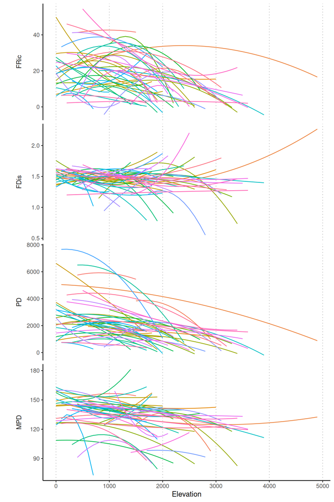

```r
quad_reg %>%
  ggplot(aes(x = elevation, y = pred, col = mountain)) +
  geom_line() +
  facet_wrap(~ metric, ncol = 1, scales = "free_y", strip.position = "left") +
  labs(x = "Elevation", y = "") +
  # scale_col_pal + # only makes sense to colour scheme after classifying into 8 categs
  theme(panel.grid.major.x = element_line(colour = "grey", linetype = "dotted"),
        # match strip format in paper
        strip.background = element_rect(colour = NA),
        strip.placement = "outside",
        strip.text = element_text(size = 10),
        # remove colour key
        legend.position = "none")
```

### Classifying elevational patterns

Next, need to classify the predicted elevational pattern for each mountain into one of eight categories: Increasing, Decreasing, Mid Peak, Mid Valley, Low Plateau (Peak), High Plateau (Peak), Low Valley, High Valley (and NS for non-significant).

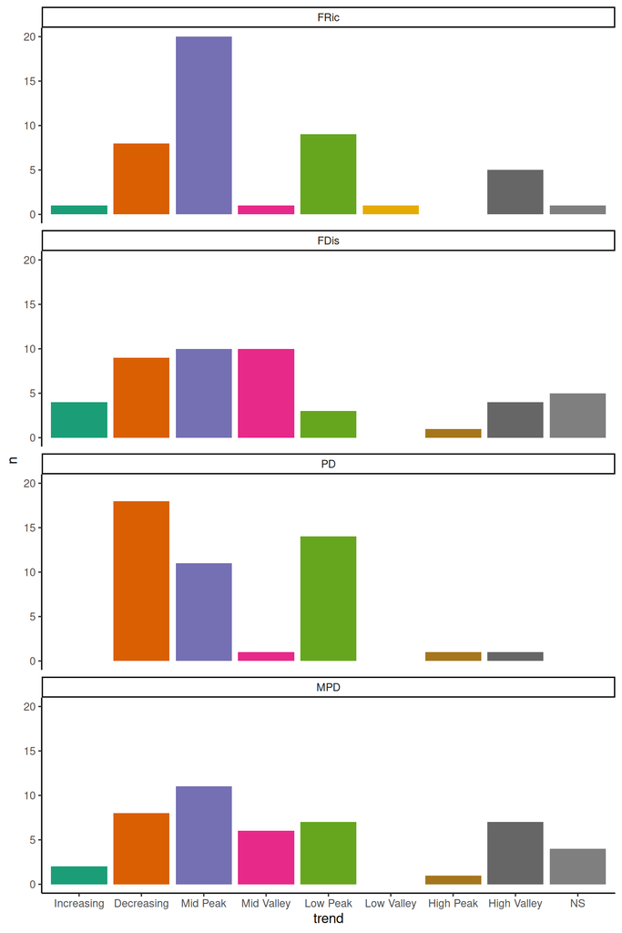

```r
# classify elevational trends

quad_reg_class <- quad_reg %>%
  get_inflection() %>%
  get_elev_cats() %>%
  class_valley_peak() %>%
  group_by(metric, mountain) %>%
  reframe(trend = case_when(
    min(pval) > 0.1 ~ "NS",

    all(inflection == FALSE) & all(pred_diff >= 0) ~ "Increasing",
    all(inflection == FALSE) & all(pred_diff <= 0) ~ "Decreasing",

    all(valleypeak == "valley") & all(!(inflection == TRUE & elev_cat != "LOW")) ~ "Low Valley",
    all(valleypeak == "valley") & all(!(inflection == TRUE & elev_cat != "HIGH")) ~ "High Valley",
    all(valleypeak == "valley") & all(!(inflection == TRUE & elev_cat != "MID")) ~ "Mid Valley",

    all(valleypeak == "peak") & all(!(inflection == TRUE & elev_cat != "LOW")) ~ "Low Peak",
    all(valleypeak == "peak") & all(!(inflection == TRUE & elev_cat != "HIGH")) ~ "High Peak",
    all(valleypeak == "peak") & all(!(inflection == TRUE & elev_cat != "MID")) ~ "Mid Peak",

    TRUE ~ NA
  ))

# plot frequency bar graph of different trend types
quad_reg_class %>%
  mutate(trend = factor(trend,
                         levels = c("Increasing", "Decreasing", "Mid Peak", "Mid Valley",
                                    "Low Peak", "Low Valley", "High Peak", "High Valley", "NS"))) %>%
  group_by(metric) %>%
  count(trend) %>%
  ggplot() +
  geom_col(aes(x = trend, y = n, fill = trend)) +
  facet_wrap(~ metric, ncol = 1) +
  scale_fill_pal +
  theme(legend.position = "none")
```

## How deterministic are these elevational patterns?

Were observed functional and phylogenetic diversities different than expected given random assembly? To answer this, the authors first constructed null models by randomising trait phylogeny tip labels over 1000 runs while fixing the rows and columns of the community data matrix. The average values of diversity metrics for this null model was then compared with the observed metrics, as deviation. These deviations were then standardised to allow comparisons across assemblages, which was referred to as Standardised Effect Size (SES).

This entire process is not reproducible, since we do not have access to the raw data. Instead, I need to start with the calculated SES values, and directly fit the linear mixed-effects model testing the diversity metrics as a function of normalised elevation scaled to between -1 and 1.

However, according to Figure 3, they have not only run this single LMM across mountains (with mountain as random effect) but have also fit new linear models for each mountain separately—as done in the previous analysis but this time using scaled elevation instead.

*For the record, there is a discrepancy in methods described in the paper; in section 2.3 on page 5 (last line), the elevation variable is said to have been normalised between -1 and 1, but according to the caption for Figure 3 (and judging from the grey raw data points plotted), elevation was actually just scaled and centred on 0.*

### Fitting individual mountain models

```r
# iterate over each mountain in the dataset:
# fit LM of each metric against linear and second-order polynomial terms of scaled elevation
# extract model predictions for each mountain

metric_sess <- glue("SES.{metric_cols}")
to_iter <- expand.grid(mountain = list_mount, metric = metric_sess)

quad_reg_ses <- map2(to_iter$mountain, to_iter$metric, ~ {

  data_mount <- data_dryad %>% filter(Mountain == .x)
  model_formula <- as.formula(glue("{.y} ~ elevation_scaled + I(elevation_scaled^2)"))
  model_mount <- lm(model_formula, data_mount)

  # predict only for elevations present in each mountain
  to_pred <- data_mount %>% distinct(Mountain, elevation_scaled)
  # predict
  model_pred <- predict(model_mount, newdata = to_pred, type = "response")
  pred <- bind_cols(to_pred, pred = model_pred)

  tibble(mountain = .x, metric = .y) %>%
    left_join(pred, by = c("mountain" = "Mountain"))

}) %>%
  list_rbind() %>%
  relocate(metric, mountain) %>% # bring metric and mountain cols to the start
  mutate(metric = gsub("\\.", " ", metric)) %>% # remove period from metric name
  mutate(metric = factor(metric,
                         levels = c("SES FRic", "SES FDis", "SES PD", "SES MPD")))

# summarise original data to plot raw data points

data_dryad_ses <- data_dryad %>%
  select(Mountain, elevation_scaled, starts_with("SES")) %>%
  pivot_longer(cols = starts_with("SES"),
               names_to = "metric", values_to = "obs") %>%
  rename(mountain = Mountain) %>%
  mutate(metric = gsub("\\.", " ", metric)) %>% # remove period from metric name
  mutate(metric = factor(metric,
                         levels = c("SES FRic", "SES FDis", "SES PD", "SES MPD")))
```

### Fitting mixed-effects model across all mountains

```r
quad_lmm_ses_output <- map(metric_sess, ~ {

  model_formula <- as.formula(glue("{.x} ~ elevation_scaled + I(elevation_scaled^2) + (1 | Mountain)"))
  model_ses <- lmer(model_formula, data_dryad, REML = FALSE) # because we use Likelihood Ratio Test

  # predict only for elevations present in each mountain
  to_pred <- data_dryad %>% distinct(elevation_scaled)
  # predict
  model_pred <- predict(model_ses, newdata = to_pred, type = "response",
                        re.form = NA)
  pred <- bind_cols(to_pred, pred = model_pred) %>% mutate(metric = .x)

  # also generate model summary for Table 1
  summ <- gen_mem_summ(model_ses) %>% mutate(metric = .x)

  # return both
  list(predicted = pred,
       summary = summ)

})

# model predictions
quad_lmm_ses <- map(quad_lmm_ses_output, "predicted") %>%
  list_rbind() %>%
  relocate(metric) %>%  # bring metric col to the start
  mutate(metric = gsub("\\.", " ", metric)) %>% # remove period from metric name
  mutate(metric = factor(metric,
                         levels = c("SES FRic", "SES FDis", "SES PD", "SES MPD")))

# model summary
quad_lmm_ses_summ <- map(quad_lmm_ses_output, "summary") %>%
  list_rbind() %>%
  relocate(metric) %>%
  # refining formatting of labels and values
  mutate(metric = gsub("\\.", " ", metric), # remove period from metric name
         term = str_replace(term, "elevation_scaled", "Elevation")) %>%
  mutate(term = if_else(str_detect(term, "\\("),
                        str_match(term, "\\(([^()]*)\\)")[, 2],
                        term) %>%
         str_replace_all("\\^2", "<sup>2</sup>")) %>%
  mutate(term = str_replace(term, "Mountain", "Mountain (random effect)")) %>%
  pivot_wider(names_from = "metric", values_from = "value") %>%
  rename(Terms = term)
```

### Plotting everything for Figure 3

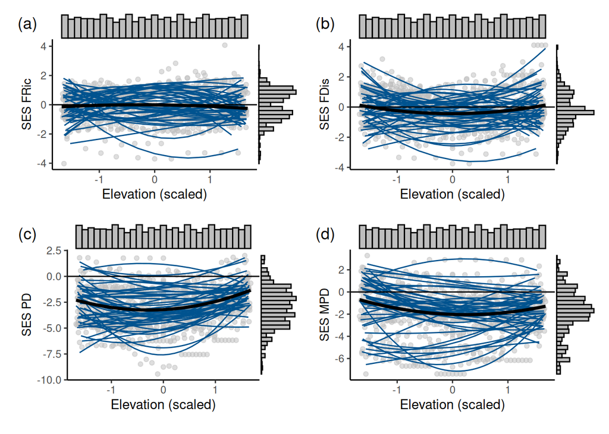

```r
fig3_panel <- function(which_metric) {

  (
    # base plot
    ggplot() +
      # raw data points
      geom_point(data = data_dryad_ses %>% filter(metric == which_metric),
                 col = "grey", alpha = 0.5,
                 mapping = aes(x = elevation_scaled, y = obs, group = mountain)) +
      # individual mountain model predictions (blue line)
      geom_line(data = quad_reg_ses %>% filter(metric == which_metric),
                col = "#00538F",
                mapping = aes(x = elevation_scaled, y = pred, group = mountain)) +
      geom_hline(yintercept = 0) +
      # overall LMM prediction across all mountains (black line)
      geom_line(data = quad_lmm_ses %>% filter(metric == which_metric),
                linewidth = 1.25,
                mapping = aes(x = elevation_scaled, y = pred)) +
      labs(x = "Elevation (scaled)", y = which_metric) +
      # match strip format in paper
      theme(axis.title.y = element_text(size = 10))
  ) %>%
    # include marginal histograms
    ggMarginal(type = "histogram", fill = "grey")

}

metric_sess_form <- gsub("\\.", " ", metric_sess)

(wrap_elements(fig3_panel(metric_sess_form[1])) |
  wrap_elements(fig3_panel(metric_sess_form[2]))) /
  (wrap_elements(fig3_panel(metric_sess_form[3])) |
     wrap_elements(fig3_panel(metric_sess_form[4]))) &
  plot_annotation(tag_levels = "a", tag_prefix = "(", tag_suffix = ")") &
  theme(plot.tag.position = c(0.05, 0.95)) # align tags with axis labels
```

And the model summary is shown in Table 1:

Table 1: Parameter estimates (with SE) of mixed-effects models. The last row shows variances of the random effect term, Mountain.

| Terms | SES FRic | SES FDis | SES PD | SES MPD |
| --- | --- | --- | --- | --- |
| Intercept | -0.007 ± 0.111 | -0.439 ± 0.118 | -3.212 ± 0.222 | -2.023 ± 0.268 |
| Elevation | -0.035 ± 0.028 | 0.004 ± 0.03 | 0.285 ± 0.036** | -0.177 ± 0.034** |
| Elevation<sup>2</sup> | -0.067 ± 0.032* | 0.2 ± 0.034** | 0.496 ± 0.041** | 0.367 ± 0.039** |
| Mountain (random effect) | 0.487 | 0.541 | 2.135 | 3.192 |

## Is our classification of elevational trends correct?

Double-checking our classification of elevational trends to see if they make sense. If not, that could explain the discordance with original results.

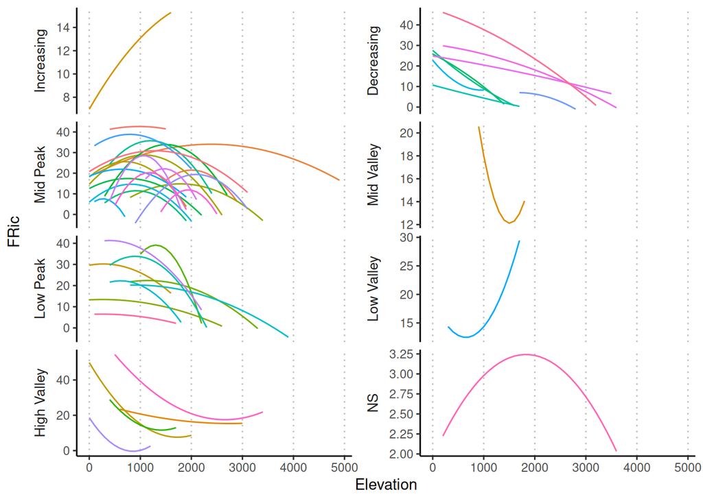

```r
# plot the trends of different trend types for each metric separately
quad_reg_class %>%
  mutate(trend = factor(trend,
                        levels = c("Increasing", "Decreasing", "Mid Peak", "Mid Valley",
                                   "Low Peak", "Low Valley", "High Peak", "High Valley", "NS"))) %>%
  right_join(quad_reg, by = c("metric", "mountain")) %>%
  filter(metric == "FRic") %>%
  ggplot(aes(x = elevation, y = pred, col = mountain)) +
  geom_line() +
  facet_wrap(~ trend, ncol = 2, scales = "free_y", strip.position = "left") +
  labs(x = "Elevation", y = "FRic") +
  # scale_col_pal + # only makes sense to colour scheme after classifying into 8 categs
  theme(panel.grid.major.x = element_line(colour = "grey", linetype = "dotted"),
        # match strip format in paper
        strip.background = element_rect(colour = NA),
        strip.placement = "outside",
        strip.text = element_text(size = 10),
        # remove colour key
        legend.position = "none")
```

This figure only shows the trends for the FRic metric. Aside from a handful of lines that look like they might belong in a different category, the overall classification seems to have worked out rather well!

How do they look when we use the scaled elevation values?

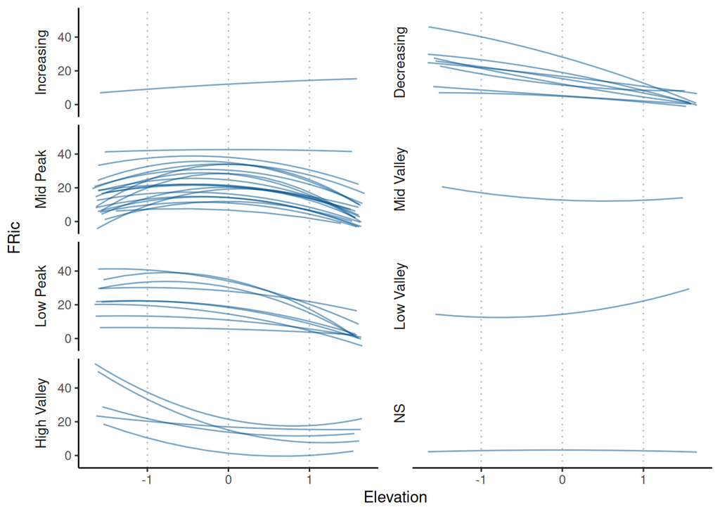

```r
quad_reg_class %>%
  mutate(trend = factor(trend,
                        levels = c("Increasing", "Decreasing", "Mid Peak", "Mid Valley",
                                   "Low Peak", "Low Valley", "High Peak", "High Valley", "NS"))) %>%
  right_join(quad_reg, by = c("metric", "mountain")) %>%
  select(metric, mountain, pred, elevation, trend) %>%
  left_join(data_dryad %>% distinct(Mountain, elevation, elevation_scaled),
            by = c("mountain" = "Mountain", "elevation")) %>%
  filter(metric == "FRic") %>%
  ggplot(aes(x = elevation_scaled, y = pred, group = mountain)) +
  geom_line(col = "#00538F", alpha = 0.5) +
  facet_wrap(~ trend, ncol = 2, strip.position = "left") +
  labs(x = "Elevation", y = "FRic") +
  theme(panel.grid.major.x = element_line(colour = "grey", linetype = "dotted"),
        # match strip format in paper
        strip.background = element_rect(colour = NA),
        strip.placement = "outside",
        strip.text = element_text(size = 10),
        # remove colour key
        legend.position = "none")
```

From this, it seems that the only discrepancies are in the peaks and valleys categories. For instance, for FRic, my method has more Mid Peaks while theirs has more Low Peaks, while there is also one misclassified Decreasing & High Valley. This probably has to do with the fact that the authors used a stringent criterion:

> Patterns were classified as […] if there is a peak/valley of diversity metrics that occurs in more than three consecutive elevational bins towards low or high elevations, respectively.

This criterion is rather ambiguous, and its implementation in my programmatic classification is not feasible. Since the majority of trends still seem to have been classified the same in both of our methods, and since the authors do not use the categories themselves as variables in any models, I am satisfied leaving my classification as is.